# index slides

[figure not shown]

## Welcome to the showcase!

**Navigation:**  
Step forward: `SPACE` | Step backward: `SHIFT`+`SPACE`  
Chapters: `←` / `→` | Subslides: `↑` / `↓`  
Overview: `Esc`

[figure not shown]

# About Draf

## What is Draf?

**Draf** stands for "**D**emand **R**esponse **A**nalysis **F**ramework" and is an easy-to-use open source decision support tool that enables the economic and ecological evaluation of industrial demand response potential. It is devoloped in Python and uses the power of Gurobi to build and solve multi-objective optimization models of industrial energy systems and production processes to quantify the cost and green-house-gas saving potentials of price based demand response. Target groups are researchers, engineers, and decision-makers of companies in industrial or commercial sectors with some basic knowledge of the Python programming language.

Draf is developed by [Markus Fleschutz](https://www.linkedin.com/in/markus-fleschutz/) in a cooperative PhD between [Cork Institute of Technology](https://www.cit.ie/) and the [Karlsruhe University of Applied Sciences](https://www.hs-karlsruhe.de/en/) and under the supervision of [Dr. Michael D. Murphy](https://ie.linkedin.com/in/michael-d-murphy-16134118) and [Dr.-Ing Marco Braun](https://www.hs-karlsruhe.de/w/ueber-uns/personen/professorinnen/prof-dr-ing-marco-braun/). More information can be found on the [website](https://messo.cit.ie/draf).

[figure not shown]

## Why Draf?

- The core-idea of demand response is to shift electric demand to hours with cheap electricity prices e.g. when shares of renewable energy sources are high.
- For industrial companies, price-based demand response is an essential and promising approach to reduce both electricity costs and – with increasing relevance – carbon emissions.
- The problem with the quantification of demand response potential is that it requires the modeling of the inventives (here: day ahead market prices and carbon dynamic emission factors) and the flexible entities (batteries, heatpumps etc.) with its most relevant constraints which can be very complex and time consuming.
- Draf solves this problem by making the quantification process of demand response potentials automated and easy-to-use. It provides market data, predefined models, modeling assistance, and visualization tools and helps the user to focus on the important aspects.

## Core areas

Draf combines several task areas that are important for the quantification of demand response potentials. The most important ones are:

1. **Easy access to electricity market data**.  
   E.g. if a case study is configured with a specific year and country, Draf downloads the according day-ahead market prices and historic national electricity generation data, preprocesses it, and prepares the real-time prices and carbon emission factors that are needed for the analysis.
2. **Several predefined models**.  
   ... of typical industrial energy systems that can easily be parameterized.
3. **Fully automated scenario generation**.  
   In a scenario, only a few parameters are changed.
4. **Several built-in analysis and visualisation tools**.

[figure not shown]

## Input/Output example

This graph gives you a feeling of typical inputs and outputs:

[figure not shown]

# A quick-start showcase

We start with a straightforward model. Let's say we have a 100 kW<sub>peak</sub> Photovoltaic System (PV), a 1 MWh<sub>el</sub> Battery Energy System (BES), and given electricity demand and want to know the cost and carbon reduction potential for price based demand response considering a 50 €/kW peak-load price and a day-ahead market price. We can use the "PV_BES"-model of draf:

[figure not shown]

Schematic depiction of model "PV_BES" with its parameters and variables.

## Case study setup & scenario generation

These few lines of codes import the model `PV_BES`, initializes a case study, adds a reference scenario, sets the default parameters from the `PV_BES`-model, changes the user-defined parameters `P_PV_CAPx_`(existing 'PV power) and `c_GRID_peak_`(electricity peak price), builds 8 scenarios (2 pricing tariffs with 4 pareto points each), improves the pareto weighting factors so that the pareto points are more equally distributed, sets the model, optimizes it and saves the whole case study.

```python
import draf
from models import PV_BES as mod

cs = draf.CaseStudy(name="ShowCase", year=2017, freq="60min", country="DE")

cs.add_REF_scen(doc="no BES").set_params(mod.params_func).update_params(
    P_PV_CAPx_=100, c_GRID_peak_=50)

cs.add_scens([("c_GRID_T", "t", ["c_GRID_RTP_T", "c_GRID_TOU_T"]),
              ("E_BES_CAPx_", "b", [1000])], nParetoPoints=4)

cs.improve_pareto_and_set_model(mod.model_func).optimize(mod.postprocess_func).save();
```

```
Using license file D:\Programme\Anaconda3\gurobi.lic
Academic license - for non-commercial use only
Successfully solved 9 scenarios with an average solving time of 0.793 seconds.
CaseStudy saved to D:/mf/draf/results/ShowCase/2019-12-10_143654_.p ( 24.3 MB)
```

## Results

The pareto curve is the main resulting diagram of the draf-analysis. It plots the total costs versus the total carbon emissions for all scenarios. Scenarios can be grouped according to key-words in order to help identify individual pareto fronts. Here, the pareto-weighting factors are denoted with α.

```python
cs.plot.pareto_curves(groups=["REF", "TOU", "RTP"], label_verbosity=4)
```

[interactive chart not shown]

[figure not shown]

# More plotting

## Parameter (input)

### Parameter scalars for all scenarios

This table shows all parameters of all scenarios with its values, unit and description.

```python
cs.plot.table("p")
```

```
Note: Bold font indicate deviation from first/reference scenario.
```

| p | REF | sc1 | sc2 | sc3 | sc4 | sc5 | sc6 | sc7 | sc8 | unit | doc |
| --- | --- | --- | --- | --- | --- | --- | --- | --- | --- | --- | --- |
| alpha_ | 0 | 0 | 0.333333 | 0.666667 | 1 | 0 | 0.333333 | 0.666667 | 1 |  | pareto weighting factor |
| n_C_ | 1.38897e-05 | 1.38897e-05 | 1.38897e-05 | 1.38897e-05 | 1.38897e-05 | 1.38897e-05 | 1.38897e-05 | 1.38897e-05 | 1.38897e-05 |  | normalization factor |
| n_CE_ | 4.31839e-09 | 4.31839e-09 | 4.31839e-09 | 4.31839e-09 | 4.31839e-09 | 4.31839e-09 | 4.31839e-09 | 4.31839e-09 | 4.31839e-09 |  | normalization factor |
| c_GRID_peak_ | 50 | 50 | 50 | 50 | 50 | 50 | 50 | 50 | 50 | €/kW_el | peak price |
| P_PV_CAPx_ | 100 | 100 | 100 | 100 | 100 | 100 | 100 | 100 | 100 | kW_peak | existing capacity PV |
| E_BES_CAPx_ | 0 | 1000 | 1000 | 1000 | 1000 | 1000 | 1000 | 1000 | 1000 | kW_el | existing capacity BES |
| eta_BES_time_ | 0.999 | 0.999 | 0.999 | 0.999 | 0.999 | 0.999 | 0.999 | 0.999 | 0.999 |  | storing efficiency |
| eta_BES_in_ | 0.999 | 0.999 | 0.999 | 0.999 | 0.999 | 0.999 | 0.999 | 0.999 | 0.999 |  | loading efficiency |
| k_BES_in_per_capa_ | 1 | 1 | 1 | 1 | 1 | 1 | 1 | 1 | 1 |  | ratio of charging power / capacity |
| k_BES_out_per_capa_ | 1 | 1 | 1 | 1 | 1 | 1 | 1 | 1 | 1 |  | ratio of discharging power / capacity (aka C rate) |
| timelog_params_ | 0.838508 | 0 | 0 | 0 | 0 | 0 | 0 | 0 | 0 | seconds | time for building the params |
| timelog_model_ | 2.79629 | 2.08576 | 2.0242 | 2.09764 | 2.09404 | 2.35387 | 2.24089 | 2.36363 | 2.07149 | seconds | time for building the model |
| mipGap_ | 0.1 | 0.1 | 0.1 | 0.1 | 0.1 | 0.1 | 0.1 | 0.1 | 0.1 | % | Gap to relaxed solution |
| timelog_solve_ | 0.324877 | 1.15911 | 1.09521 | 1.14603 | 0.508448 | 0.905575 | 0.906073 | 0.782783 | 0.310037 | seconds | time for solving the model |

For all non-scalars entities, the `describe` function gives an overview of one ore many scenarios:

```python
cs.plot
```

```
<draf.plotting.cs_plotting.CsPlotter at 0x26543d2a308>
```

```python
sc = cs.scens.sc1
sc.plot.describe(include_vars=False)
```

```
================================================================================
tc_GRID_RTP_T_b1000_a0.0: Parameters
  doc = c_GRID_T=c_GRID_RTP_T; E_BES_CAPx_=1000; alpha_=0.0
================================================================================

 ---------
alpha_                 0.00000
n_C_                   0.00001
n_CE_                  0.00000
c_GRID_peak_          50.00000 €/kW_el
P_PV_CAPx_           100.00000 kW_peak
E_BES_CAPx_            1.00000 MW_el
eta_BES_time_          0.99900
eta_BES_in_            0.99900
k_BES_in_per_capa_        1.00000
k_BES_out_per_capa_        1.00000
timelog_params_        0.00000 seconds
timelog_model_         2.08576 seconds
mipGap_                0.10000 %
timelog_solve_         1.15911 seconds

T ---------
                         sum        mean         min         max  \
ce_GRID_T       4.835891e+06  552.042355  168.163680  846.098705
E_dem_T         5.000000e+05   57.077626   40.242549   76.965997
c_GRID_addon_T  1.148261e+03    0.131080    0.131080    0.131080
E_PV_profile_T  9.415523e+02    0.107483    0.000000    0.814534
c_GRID_TOU_T    2.994915e+02    0.034189    0.029372    0.043550
c_GRID_RTP_T    2.994915e+02    0.034189   -0.083060    0.163520
c_GRID_T        2.994915e+02    0.034189   -0.083060    0.163520


ce_GRID_T       gCO2eq/kWh_el
E_dem_T                kWh_el
c_GRID_addon_T       €/kWh_el
E_PV_profile_T  kW_el/kW_peak
c_GRID_TOU_T         €/kWh_el
c_GRID_RTP_T         €/kWh_el
c_GRID_T             €/kWh_el
```

## Heatmaps

Heatmaps are the perfect plot type to see seasonal and daily patterns of a whole year's timeseries.

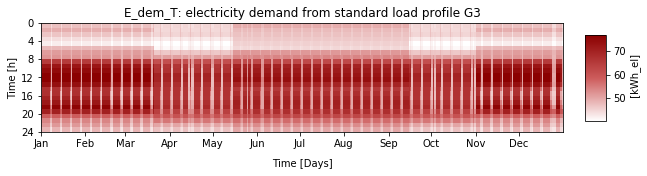

```python
sc.plot.heatmap(ent_name="E_dem_T")
```

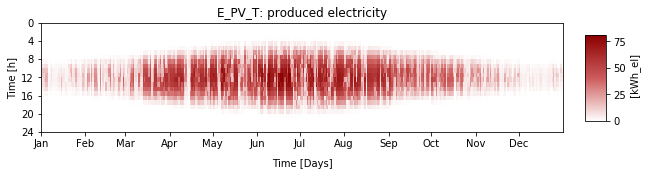

```python
sc.plot.heatmap(ent_name="E_PV_T")
```

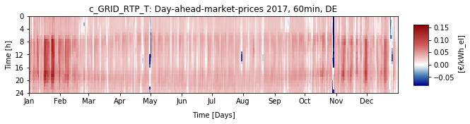

```python
sc.plot.heatmap(ent_name="c_GRID_RTP_T")
```

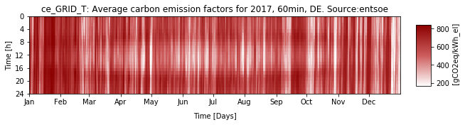

```python
sc.plot.heatmap(ent_name="ce_GRID_T")
```

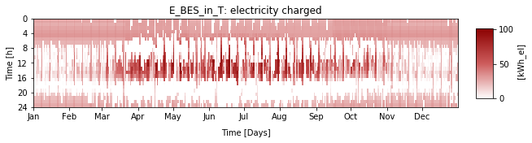

```python
sc.plot.heatmap(ent_name="E_BES_in_T")
```

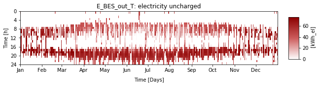

```python
sc.plot.heatmap(ent_name="E_BES_out_T")
```

## Variables / Results (output)

### Scalars for all scenarios

This code produces a table of all scalar variables of the model with its resulting values, units, and descriptions.

```python
cs.plot.table("v")
```

```
Note: Bold font indicate deviation from first/reference scenario.
```

| v | REF | sc1 | sc2 | sc3 | sc4 | sc5 | sc6 | sc7 | sc8 | unit | doc |
| --- | --- | --- | --- | --- | --- | --- | --- | --- | --- | --- | --- |
| C_ | 71995.9 | 69008.8 | 69770 | 72336.9 | 118511 | 69541.1 | 70940 | 75039.7 | 121804 | €/a | total costs |
| C_inv_ | 0 | 0 | 0 | 0 | 0 | 0 | 0 | 0 | 0 | € | investment costs |
| C_op_ | 71995.9 | 69008.8 | 69770 | 72336.9 | 118511 | 69541.1 | 70940 | 75039.7 | 121804 | €/a | operating costs |
| CE_ | 2.31568e+08 | 2.14108e+08 | 2.01786e+08 | 1.93712e+08 | 1.89929e+08 | 2.28803e+08 | 2.07706e+08 | 1.94421e+08 | 1.90349e+08 | gCO2eq/a | total emissions |
| C_GRID_peak_ | 3799.13 | 3732.58 | 4930.15 | 7867.6 | 53522.1 | 2943.47 | 3843.64 | 7214.17 | 53553.6 | €/a | costs for peak price |
| P_GRID_peak_ | 75.9826 | 74.6517 | 98.603 | 157.352 | 1070.44 | 58.8694 | 76.8728 | 144.283 | 1071.07 | kW_el | peak electricity |
| C_GRID_buy_ | 68210.1 | 65276.2 | 64839.8 | 64469.3 | 64988.9 | 66597.6 | 67096.4 | 67825.5 | 68250.3 | €/a | cost for bought electricity |
| C_GRID_sell_ | 13.4039 | 0 | 0 | 0 | 0 | 0 | 0 | 0 | 0 | €/a | earnings for bought electricity |

### Variables Summary for scenario "sc1"

```python
cs.scens.sc1.plot.describe(include_pars=False)
```

```
================================================================================
tc_GRID_RTP_T_b1000_a0.0: Variables
  doc = c_GRID_T=c_GRID_RTP_T; E_BES_CAPx_=1000; alpha_=0.0
================================================================================

 ---------
C_                    69.00879 Thousand €/a
C_inv_                 0.00000 €
C_op_                 69.00879 Thousand €/a
CE_                  214.10811 tCO2eq/a
C_GRID_peak_           3.73258 Thousand €/a
P_GRID_peak_          74.65168 kW_el
C_GRID_buy_           65.27621 Thousand €/a
C_GRID_sell_           0.00000 €/a

T ---------
                        sum        mean  min          max
E_BES_T        2.548201e+06  290.890549  0.0  1000.000000  kWh_el
E_GRID_buy_T   4.083512e+05   46.615433  0.0    74.651680  kWh_el
E_BES_in_T     1.523552e+05   17.392150  0.0   101.877687  kWh_el
E_BES_out_T    1.498488e+05   17.106028 -0.0    75.982645  kWh_el
E_PV_T         9.415523e+04   10.748314  0.0    81.453351  kWh_el
E_PV_OC_T      9.415523e+04   10.748314  0.0    81.453351  kWh_el
E_GRID_sell_T  0.000000e+00    0.000000  0.0     0.000000  kWh_el
E_PV_FI_T      0.000000e+00    0.000000  0.0     0.000000  kWh_el
```

## Pareto front

```python
cs.plot.pareto_curves(groups=["REF", "TOU", "RTP"])
```

[interactive chart not shown]

## Sankey

The sankey plot shows the yearly energy sums of key energy flows from left (source) to right (cradle). You can hover over to see the numbers:

```python
cs.scens.sc1.plot.sankey(mod.sankey_func)
```

[interactive chart not shown]

[figure not shown]

# Features / modules

## Saving & Loading of case studies

At any time, you can save the case study to hard disk like so:

```python
cs.save("test");
```

```
CaseStudy saved to D:/mf/draf/results/ShowCase/2019-12-10_143657_test.p ( 33.7 MB)
```

... and open it later again:

```python
import draf
cs = draf.CaseStudy(fp="D:/mf/draf/results/ShowCase/2019-12-10_143657_test.p")
```

## Data export

Draf is compatible with the powerful `xarray`-module. Here, parameters and results are comined into one big dataset:

```python
cs.scens.REF.get_xarray_dataset()
```

```
<xarray.Dataset>
Dimensions:         (T: 8760)
Coordinates:
  * T               (T) int64 0 1 2 3 4 5 6 ... 8754 8755 8756 8757 8758 8759
Data variables:
    E_GRID_buy_T    (T) float64 44.33 46.08 43.76 41.85 ... 47.83 45.88 43.15
    E_GRID_sell_T   (T) float64 0.0 0.0 0.0 0.0 0.0 0.0 ... 0.0 0.0 0.0 0.0 0.0
    E_PV_T          (T) float64 0.0 0.0 0.0 0.0 0.0 0.0 ... 0.0 0.0 0.0 0.0 0.0
    E_PV_OC_T       (T) float64 0.0 0.0 0.0 0.0 0.0 0.0 ... 0.0 0.0 0.0 0.0 0.0
    E_PV_FI_T       (T) float64 0.0 0.0 0.0 0.0 0.0 0.0 ... 0.0 0.0 0.0 0.0 0.0
    E_BES_T         (T) float64 0.0 0.0 0.0 0.0 0.0 0.0 ... 0.0 0.0 0.0 0.0 0.0
    E_BES_in_T      (T) float64 0.0 0.0 0.0 0.0 0.0 0.0 ... 0.0 0.0 0.0 0.0 0.0
    E_BES_out_T     (T) float64 -0.0 -0.0 -0.0 -0.0 -0.0 ... -0.0 -0.0 -0.0 -0.0
    ce_GRID_T       (T) float64 507.9 518.0 514.5 525.0 ... 241.2 253.3 241.1
    c_GRID_RTP_T    (T) float64 0.02096 0.0209 0.01813 ... 0.00186 -0.00092
    c_GRID_TOU_T    (T) float64 0.02937 0.02937 0.02937 ... 0.02937 0.02937
    c_GRID_T        (T) float64 0.02096 0.0209 0.01813 ... 0.00186 -0.00092
    c_GRID_addon_T  (T) float64 0.1311 0.1311 0.1311 ... 0.1311 0.1311 0.1311
    E_dem_T         (T) float64 44.33 46.08 43.76 41.85 ... 47.83 45.88 43.15
    E_PV_profile_T  (T) float64 0.0 0.0 0.0 0.0 0.0 0.0 ... 0.0 0.0 0.0 0.0 0.0
```

## Spot market prices

Draf provides day ahead spot market prices for several European countries and years.

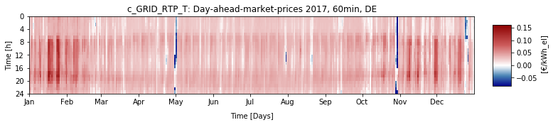

```python
sc = cs.scens.REF
sc.plot.fig_size = (12,1)

sc.prep.add_c_GRID_RTP_T()
sc.plot.heatmap(ent_name="c_GRID_RTP_T")
```

## Carbon emission factors

Draf provides dynamic carbon emission factors for several European countries and years.

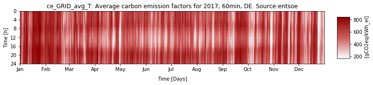

```python
sc.prep.add_ce_GRID_T(name="ce_GRID_avg_T", method="average")
sc.plot.heatmap(ent_name="ce_GRID_avg_T")
```

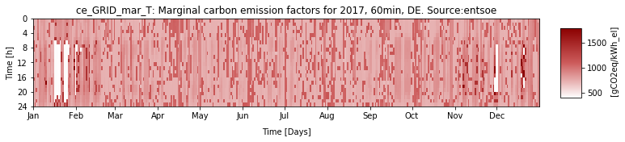

```python
sc.prep.add_ce_GRID_T(name="ce_GRID_mar_T", method="marginal")
sc.plot.heatmap(ent_name="ce_GRID_mar_T")
```

## Timeseries Preparation

Draf provides some useful tools for demand estimation. These are especially useful when only aggregated values are availible.

First, we prepare an electricity demand from a industrial standard load profile "G1" which stands for Business on weekdays 08:00 - 18:00 and an given annual energy demand of 5 GWh/a.

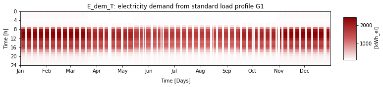

```python
sc = draf.CaseStudy(year=2017).add_REF_scen()
sc.prep.add_E_dem_T(profile="G1", annual_energy=5e6, holidays_province="BY")
sc.plot.fig_size = (12,1)
sc.plot.heatmap(ent_name="E_dem_T")
```

```python
sc.params.E_dem_T.sum()
```

```
5000000.0
```

Now let's create an heat demand timeseries from the annual energy, the target_temperatur, the heating threshold and the location where the ambient temperature is taken.

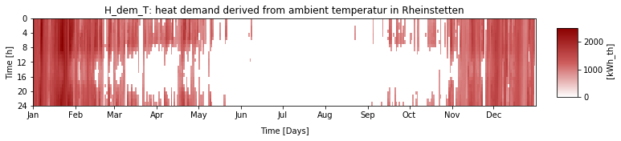

```python
sc.prep.add_H_dem_T(annual_energy=5e6, target_temp=20.0, threshold_temp=10.0, location='Rheinstetten')
sc.plot.heatmap(ent_name="H_dem_T")
```

This is the ambient temperature that was used as basis:

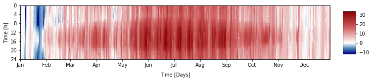

```python
sc.plot.heatmap(timeseries=draf.prep.io.get_amb_temp(year=cs.year, freq=cs.freq, location="Rheinstetten"))
```

## Model templates

Draf comes with some out-of-the-box models for different relevant aggregates in the industrial environment that can easily be parameterized. One of the models is "DER_HUT" - Distribted Energy Ressources(DER) and Heat upgrading Technologies (HUT). Here is a schematic:

[figure not shown]

### By the way:

The PV_BES from the quickstart showcase:

[figure not shown]

is a submodel of the DER_HUT:

[figure not shown]

## Access to Draf-objects

In the following, access and preview of draf-objects (CaseStudy, Scenario, etc.) is demonstrated.

### Case Study

```python
cs
```

```
<CaseStudy object>
• name: ShowCase
• doc: No doc available.
• freq: 60min
• country: DE
• is_dry_run: False
• scens: [...]
• plot: <draf.plotting.cs_plotting.CsPlotter object at 0x0000026543D2A308>
• dims: <Dimensions object> (empty)
• params: <Params object> (empty)
• obj_vars: ['C_', 'CE_']
• year: 2017
• dtindex: [...]
• dtindex_custom: [...]
• steps_per_day: 24
• scen_vars: [('c_GRID_T', 't', ['c_GRID_RTP_T', 'c_GRID_TOU_T']), ('E_BES_CAPx_', 'b', [1000]), ('alpha_', 'a', array([0.        , 0.33333333, 0.66666667, 1.        ]))]
• scen_df: [...]
• dt_info:
  ⤷ t1 = 0     (Sunday, 2017-01-01 00:00:00),
  ⤷ t2 = 8759  (Sunday, 2017-12-31 23:00:00)
  ⤷ Length = 8760
```

### Scenarios

```python
cs.scens
```

```
<Scenarios object>
   name         doc
  ⤷ REF        | no BES
  ⤷ sc1        | c_GRID_T=c_GRID_RTP_T; E_BES_CAPx_=1000; alpha_=0.0
  ⤷ sc2        | c_GRID_T=c_GRID_RTP_T; E_BES_CAPx_=1000; alpha_=0.3333333333333333
  ⤷ sc3        | c_GRID_T=c_GRID_RTP_T; E_BES_CAPx_=1000; alpha_=0.6666666666666666
  ⤷ sc4        | c_GRID_T=c_GRID_RTP_T; E_BES_CAPx_=1000; alpha_=1.0
  ⤷ sc5        | c_GRID_T=c_GRID_TOU_T; E_BES_CAPx_=1000; alpha_=0.0
  ⤷ sc6        | c_GRID_T=c_GRID_TOU_T; E_BES_CAPx_=1000; alpha_=0.3333333333333333
  ⤷ sc7        | c_GRID_T=c_GRID_TOU_T; E_BES_CAPx_=1000; alpha_=0.6666666666666666
  ⤷ sc8        | c_GRID_T=c_GRID_TOU_T; E_BES_CAPx_=1000; alpha_=1.0
```

### Scenario

```python
cs.scens.REF
```

```
<Scenario object>
• id: REF
• name: REF
• doc: no BES
• is_dry_run: False
• dims: [...]
• params: [...]
• plot: <draf.plotting.scen_plotting.ScenPlotter object at 0x0000026543E0E4C8>
• prep: <draf.prep.params_prepping.Prepper object at 0x0000026543E0EF08>
• vars: [...]
• dtindex: [...]
• dtindex_custom: [...]
• res: [...]
```

### Params

```python
cs.scens.REF.params
```

```
<Params object>
   name                 dims       unit doc
  ⤷ alpha_                   |          |pareto weighting factor
  ⤷ n_C_                     |          |normalization factor
  ⤷ n_CE_                    |          |normalization factor
  ⤷ ce_GRID_T               T|gCO2eq/kWh_el|Average carbon emission factors for 2017, 60min, DE. Source:entsoe
  ⤷ c_GRID_peak_             |   €/kW_el|peak price
  ⤷ c_GRID_RTP_T            T|  €/kWh_el|Day-ahead-market-prices 2017, 60min, DE
  ⤷ c_GRID_TOU_T            T|  €/kWh_el|Time-Of-Use-tariff with the prices 0.029€ and 0.044€
  ⤷ c_GRID_T                T|  €/kWh_el|chosen electricity tariff
  ⤷ c_GRID_addon_T          T|  €/kWh_el|add-on electricity price component
  ⤷ E_dem_T                 T|    kWh_el|electricity demand from standard load profile G3
  ⤷ P_PV_CAPx_               |   kW_peak|existing capacity PV
  ⤷ E_PV_profile_T          T|kW_el/kW_peak|produced PV-power for 1 kW_peak
  ⤷ E_BES_CAPx_              |     kW_el|existing capacity BES
  ⤷ eta_BES_time_            |          |storing efficiency
  ⤷ eta_BES_in_              |          |loading efficiency
  ⤷ k_BES_in_per_capa_       |          |ratio of charging power / capacity
  ⤷ k_BES_out_per_capa_      |          |ratio of discharging power / capacity (aka C rate)
  ⤷ timelog_params_          |   seconds|time for building the params
  ⤷ timelog_model_           |   seconds|time for building the model
  ⤷ mipGap_                  |         %|Gap to relaxed solution
  ⤷ timelog_solve_           |   seconds|time for solving the model
  ⤷ ce_GRID_avg_T           T|gCO2eq/kWh_el|Average carbon emission factors for 2017, 60min, DE. Source:entsoe
  ⤷ ce_GRID_mar_T           T|gCO2eq/kWh_el|Marginal carbon emission factors for 2017, 60min, DE. Source:entsoe
```

choose one of them, e.g. `P_PV_CAPx_`:

```python
cs.scens.REF.params.P_PV_CAPx_
```

```
100
```

### Results

```python
cs.scens.REF.res
```

```
<Results object>
   name                 dims       unit doc
  ⤷ C_                       |       €/a|total costs
  ⤷ C_inv_                   |         €|investment costs
  ⤷ C_op_                    |       €/a|operating costs
  ⤷ CE_                      |  gCO2eq/a|total emissions
  ⤷ C_GRID_peak_             |       €/a|costs for peak price
  ⤷ E_GRID_buy_T            T|    kWh_el|bought el. from the grid
  ⤷ E_GRID_sell_T           T|    kWh_el|sold el. to the grid
  ⤷ P_GRID_peak_             |     kW_el|peak electricity
  ⤷ C_GRID_buy_              |       €/a|cost for bought electricity
  ⤷ C_GRID_sell_             |       €/a|earnings for bought electricity
  ⤷ E_PV_T                  T|    kWh_el|produced electricity
  ⤷ E_PV_OC_T               T|    kWh_el|own consumption
  ⤷ E_PV_FI_T               T|    kWh_el|feed-in
  ⤷ E_BES_T                 T|    kWh_el|electricity stored
  ⤷ E_BES_in_T              T|    kWh_el|electricity charged
  ⤷ E_BES_out_T             T|    kWh_el|electricity uncharged
```

choose one of them, e.g. `C_`:

```python
cs.scens.REF.res.C_
```

```
71995.86036638569
```